# Module 4: Data Exploration

```r
# for details on this data set
?mtcars

# let's factor cyl, vs, and am.
mtcars$cyl <- factor(mtcars$cyl, levels = c(4, 6, 8),
                     labels = c('Four Cylinder',
                                'Six Cylinder',
                                'Eight Cylinder'))
mtcars$vs <- factor(mtcars$vs, levels = 0:1,
                    labels = c('V-shaped', 'straight'))
mtcars$am <- factor(mtcars$am, levels = 0:1,
                    labels = c('automatic', 'manual'))
summary(mtcars)
```

```
##       mpg                    cyl          disp             hp
##  Min.   :10.40   Four Cylinder :11   Min.   : 71.1   Min.   : 52.0
##  1st Qu.:15.43   Six Cylinder  : 7   1st Qu.:120.8   1st Qu.: 96.5
##  Median :19.20   Eight Cylinder:14   Median :196.3   Median :123.0
##  Mean   :20.09                       Mean   :230.7   Mean   :146.7
##  3rd Qu.:22.80                       3rd Qu.:326.0   3rd Qu.:180.0
##  Max.   :33.90                       Max.   :472.0   Max.   :335.0
##       drat             wt             qsec              vs
##  Min.   :2.760   Min.   :1.513   Min.   :14.50   V-shaped:18
##  1st Qu.:3.080   1st Qu.:2.581   1st Qu.:16.89   straight:14
##  Median :3.695   Median :3.325   Median :17.71
##  Mean   :3.597   Mean   :3.217   Mean   :17.85
##  3rd Qu.:3.920   3rd Qu.:3.610   3rd Qu.:18.90
##  Max.   :4.930   Max.   :5.424   Max.   :22.90
##          am          gear            carb
##  automatic:19   Min.   :3.000   Min.   :1.000
##  manual   :13   1st Qu.:3.000   1st Qu.:2.000
##                 Median :4.000   Median :2.000
##                 Mean   :3.688   Mean   :2.812
##                 3rd Qu.:4.000   3rd Qu.:4.000
##                 Max.   :5.000   Max.   :8.000
```

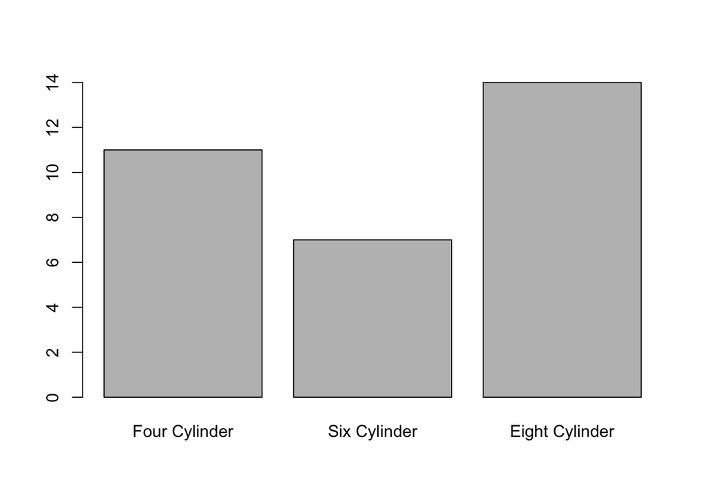

```r
plot(mtcars$cyl)
```

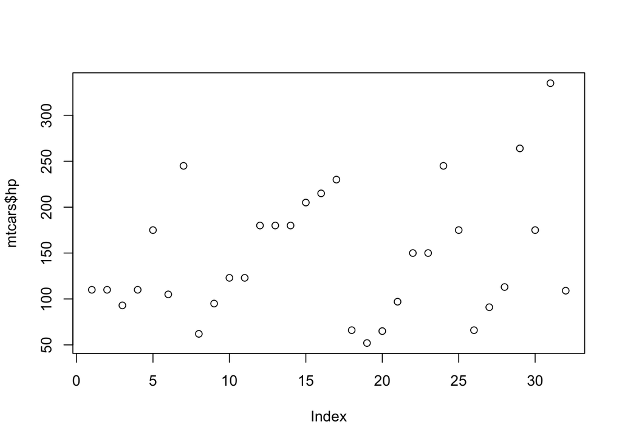

```r
plot(mtcars$hp)
```

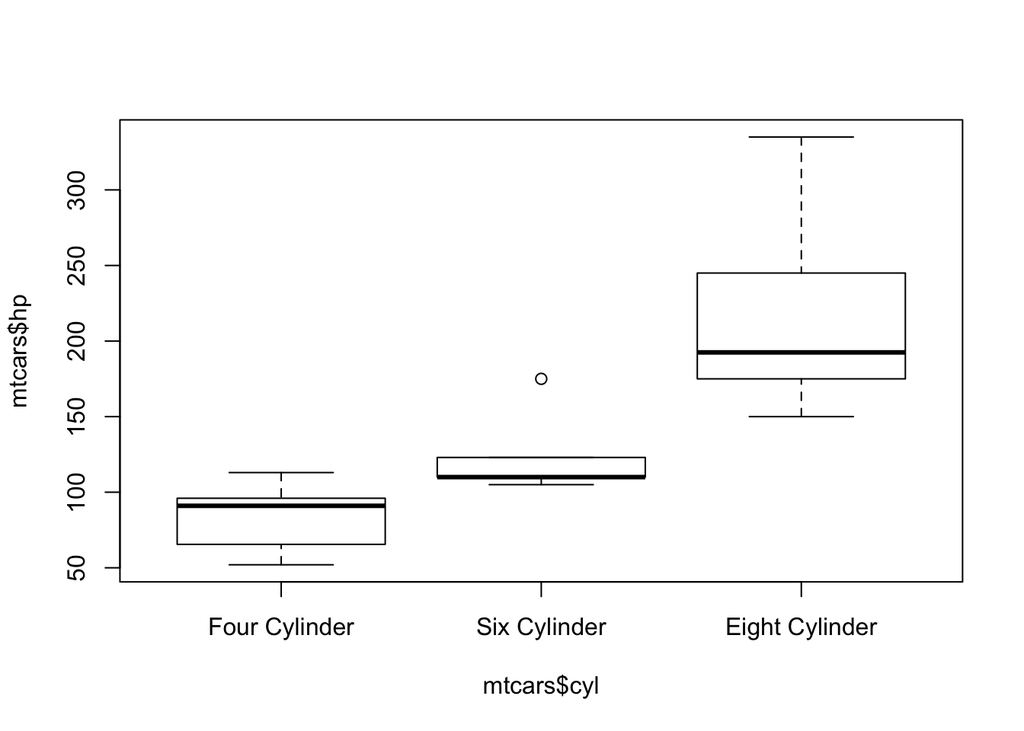

```r
plot(mtcars$hp ~ mtcars$cyl)
```

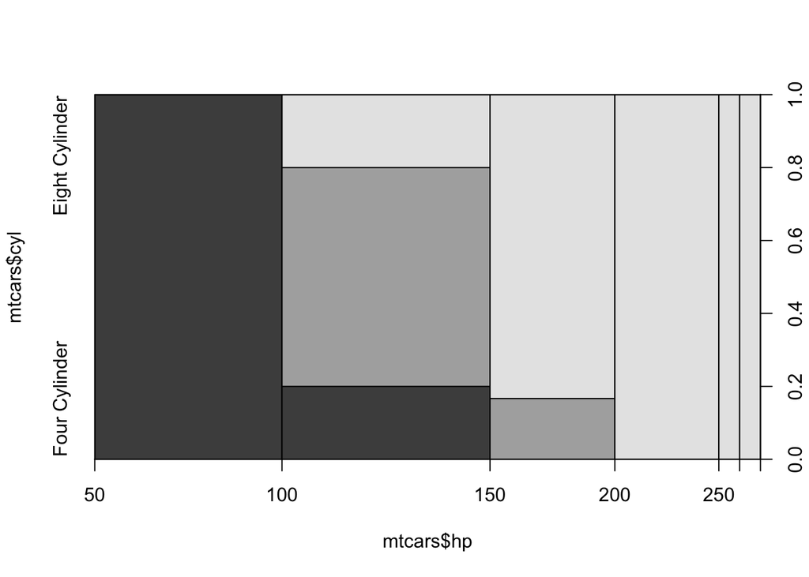

```r
plot(mtcars$cyl ~ mtcars$hp)
```

Does it appear there is a relationship between horse power and number of cylinders?

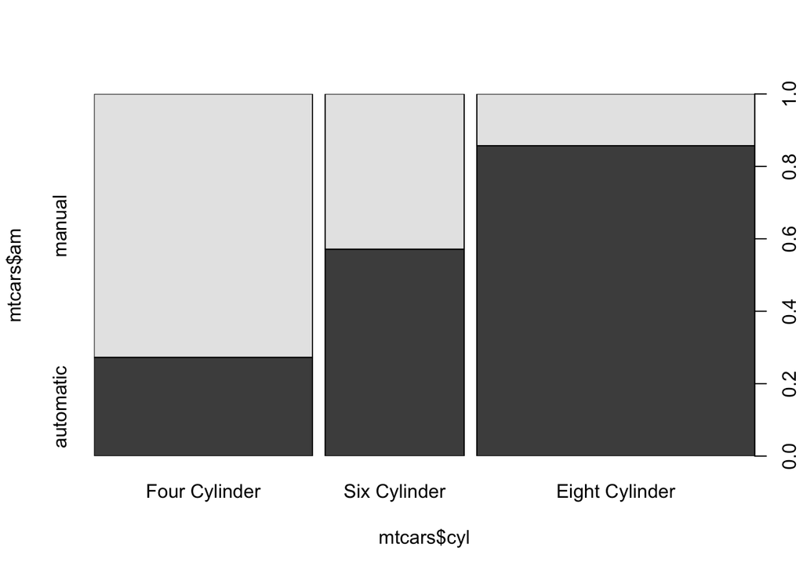

```r
plot(mtcars$am ~ mtcars$cyl)
```

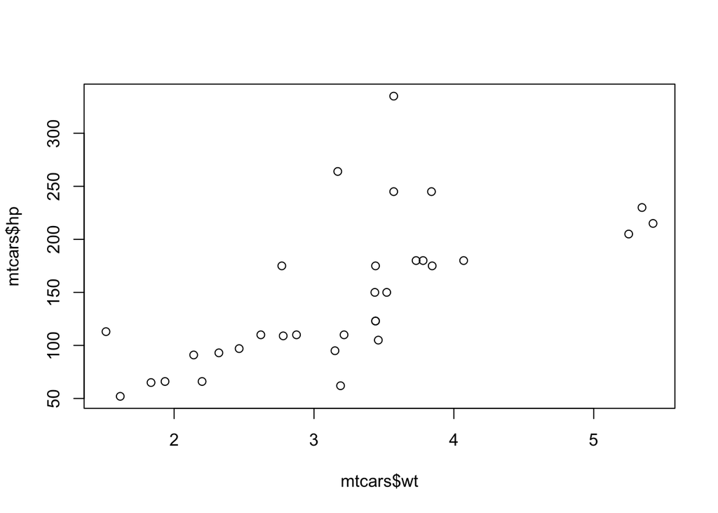

```r
plot(mtcars$hp ~ mtcars$wt)
```

Do you think there’s an association between transmission type and number of cylinders? How about between horse power and weight?

Let’s look at a histogram of miles per gallon.

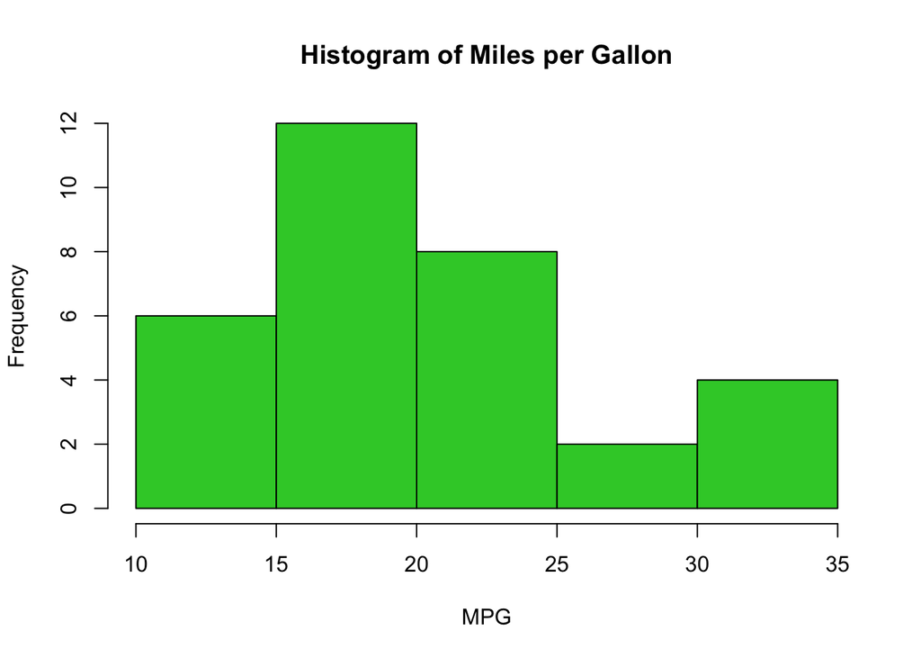

```r
hist(mtcars$mpg,
     col = '#33cc33',
     main = 'Histogram of Miles per Gallon',
     xlab = 'MPG')
```

Use ?hist, ?plot, and ?par to explore further graphing options. For further study check out [Quick-R: Graphs](https://www.statmethods.net/graphs/index.html) and [Quick-R: Advanced Graphs](https://www.statmethods.net/advgraphs/index.html).

### Saving Graphs

The easiest way to save graphs is to use the export button on the plot viewer in Rstudio.